# Analyzing RNA-binding protein profiles from eCLIP dat

Quinn Eberhard, Anastacia Wienecke, Kwame Forbes, and Chenghao Wang

2022-12-02

## Introduction/Biological Relevance

Long non-coding RNA (lncRNA) is a form of RNA that is longer than 200 nucleotides and does not encode a protein. For decades, these were considered to be “junk” RNAs as their functions were not yet known, but through extensive experimentation it has become clear that lncRNAs frequently associate with proteins to perform a variety of functions, such as epigenetics, chromatin regulation, and altering transcription and translation. One common example is the lncRNA XIST, known for repressing the additional X chromosome in female placental mammals during early development. However, protein coding RNAs also interact with proteins, so this phenomenon alone does not explain what gives lncRNAs their functions, Rather, a combination of *which* proteins bind the RNA and *where* they bind the RNA may be more informative in determining which lncRNAs have similar functions.

One way to measure this is through an assay known as eCLIP (enhanced CrossLinking ImmunoPrecipitation). A protein of interest is added to a cell where it binds to RNAs with relevant sequence or structural motifs. An antibody that is specific to the protein is used to extract the protein, bringing with it the bound RNAs. These RNAs are then fragmented and the portions that were bound to the protein are sequenced, resulting in an understanding of both which RNAs bind the protein and what portion of each RNAs *sequence* is relevant to binding the protein.

This assay is performed one protein at a time, yet Gene Yeo’s lab has uploaded 135 K562 assays and 103 HEPG2 assays to the ENCODE database. Their findings have been documented in Nature Methods (Nostrand et al., 2016), and their precise methods to obtain the data on Encode is detailed in the ‘General Protocol’ section of each experiment on ENCODE (Nostrand & Yeo, 2015). For each experiment, four different libraries were used to document the eCLIP data. Two were performed using eCLIP on UV crosslinked replicates, one was eCLIP on a non-UV crosslinked replicate, and one was developed with a control of a similar size to one of the two UV crosslinked replicates. For each sample, the cells were lysed and the three eCLIP samples were taken from the lysis pellets.

ENCODE enforces data standards for experiments to be published there, and in order to meet the standards for biological replicates the samples were taken from different distinctly different cultures from the same source. Next, beads were prepared and added to the samples in order to bind the antibodies. The lysate was treated with DNase, RNase I, and then Murine RNase Inhibitor, centrifuged, and the supernatant was retained separately. Antibody beads were then washed in iCLIP lysis buffer, some backups were stored of each sample, and then processed in a cold room for a minimum of two hours. The beads were then washed, treated with FastAP and PNK, and washed again. The 3’ RNA linkers were the ligated on the beads, and the prepared for CLIP and Western gels. CLIP gels assist with membrane transfer and RNA isolation while Western gels are used for Western imaging/protein detection. An igG IP is performed on the Western gel to guarantee the specificity of the antibodies used for extraction. Once these gels have been run, the samples are transferred to membranes, allowed to develop, and then RNA is cut out of the membranes and extensively purified. Ultimately, the samples are reverse transcribed before being quantified with qPCR and then PCR amplified.

Here we use this data to construct a **protein binding profile** for each RNA transcript in the cell in order to determine which proteins bind or do not bind to each transcript. In this report, we identify differences between the protein association to RNA transcripts in K562 and HEPG2 cells and investigate whether RNA function can be predicted from which proteins it binds. We fully anticipate differences in part due to the nature of the two cell lines, K562 cells are from a 52 year old female chronic myelogenous leukemia (CML) patient, sampled from the bone marrow and therefore a blood tissue. In contrast, HEPG2 cells are from a 15 year old male hepatocellular carcinoma patient, sampled from the liver. These samples vary in age, sex, and tissue type. Both are also cancer cell lines, though not of the same type of cancer. We expect extensive variation of a result of these factors. One easily identifiable with lncRNAs will be the absence of XIST in the HEPG2 cells, as only females can express XIST. As this lncRNA is valuable in functional reference, this might complicate HEPG2 analysis, but intra-K562 analysis will still be able to use XIST information effectively.

## Methods

### Constructing the SummarizedExperiments

Here we analyzed the RNA-protein binding preferences of two human cell lines: K562 and HEPG2 cells. K562 cells are from a 52 year old female with erythroleukemia cancer, and HEPG2 cells are hepatocellular carcinoma cells from a 15 year old male. Both have been thoroughly studied for biological analyses but here we wanted to identify similarities and differences between them in the context of eCLIP assays.

ENCODE provides these datasets for easy pre-processed file downloads, so we downloaded the bam files for all experiments for each cell type:

```bash
#mkdir downloaded_files
#cd downloaded_files
#cp ../download_K562_files.txt .
#xargs -L 1 curl -O -J -L < download_K562_files.txt
#cp metadata.tsv metadata_K562.tsv
#rm metadata.tsv
```

The pre-processed bam files were developed using the Yeo lab’s ‘eCLIP-seq Processing Pipeline’, which prepares sequence data for ready analysis (Yeo, 2020). Fastq formatted sequencing data is processed for paired-end reads if relevant, removing UMIs and barcodes. Adapters are trimmed, repeat elements are mapped and filtered, and then reads are mapped to the genome using the STAR aligner. PCR duplicates are then extracted, custom inline barcodes and filters are merged, and peak regions are then called. Lastly, data is normalized to the size-matched sample performed as part of the experiment as mentioned earlier, and fold change enrichment in the peaks is called. The custom scripts are all available through the Yeo lab Github eCLIP page. The bam files developed in this process are used for our analysis here.

No bam files were included in this repository, however, the downloaded `K562_se/K562_metadata.tsv` file is included in the `developing_se/` directory and includes information on all of the downloaded files for each experiment, which was later used to develop the colData() of the SummarizedExperiments. The `K562_se/develop_K562_column_data.py` and `HEPG2_se/develop_HEPG2_column_data.py` files show how the column data was obtained for each experiment out of the `K562_se/K562_metadata.tsv` and `HEPG2_se/HEPG2_metadata.tsv` files, resulting in `K562_se/column_data_K562.tsv` and `HEPG2_se/column_data_HEPG2.tsv` which are loaded into SummarizedExperiment colData() below.

The file `bam_file_mappings.tsv` was generated from the HEPG2 or K562 versions of the `map_bam_replicates.py` script. There were two replicates for each experiment, so we merged the bam files using `samtools merge` for each replicate, then ran featureCounts to determine the RBP counts (script in `serial_bam_merge.sh`). featureCounts is a tool in the Subreads package developed by Yang Liao and Wei Shi that quantifies the instances of genomic features in sequence reads. This allowed us to determine for each experiment how many reads mapped to each transcript (`developing_se/feature_counts.sh`). This would ultimately develop one column of the SummarizedExperiment. The `gencode.v39.basic.annotation.gtf` genome was downloaded from GENCODE for GRCh38.p13 and was used for featureCount annotation. This gtf file then also informed the development of the rowData() of the SummarizedExperiments.

In the K562 development, several of the eCLIP experiments were done as single end reads rather than paired ends. Those were identified from errors in the initial `feature_counts.sh` attempt and were manually corrected for in the `developing_se/single_end_feature_counts.sh` file, where the rest were processed, this step was not necessary for the HEPG2 cell experiments. All featureCounts results were compiled in the `developing_se/make_count_matrix.py` script - this must be run separately for each cell type data.

The SummarizedExperiment was developed by the code in `developing_se/K562_se/loading_K562_se_object.Rmd` and the .Rda object is generated and stored in the derived_data/ directory of the repository. This code is also located below. The individual matrices of the asssay(), colData(), and rowData() are also included in the files K562_assay.tsv, K562_colData.tsv, and K562_rowData.tsv.

```r
#Read in count matrix and column data
K562_counts <- read.csv("developing_se/K562_se/main_featcount_K562.tsv", sep="\t")
K562_column_data <- read.csv("developing_se/K562_se/column_data_K562.tsv", sep="\t")
#Order the column data to match the order of the count matrix
K562_column_data <- K562_column_data[ order(match(K562_column_data$Experiment.accession, colnames(K562_counts))), ]
rownames(K562_column_data) <- NULL
#Repeat for the row data
K562_row_data <- read.csv("developing_se/rowdata.tsv", sep="\t")
K562_column_data <- column_to_rownames(K562_column_data, "Experiment.accession")
K562_counts <- column_to_rownames(K562_counts, "Gene.id")
K562_row_data <- column_to_rownames(K562_row_data, "Gene_id")
K562.se <- SummarizedExperiment(assays = list(counts = data.matrix(K562_counts)), colData = K562_column_data, rowData=K562_row_data)
```

Once the initial SummarizedExperiment was constructed, it was necessary to perform basic filtering to remove any genes that are not expressed in any of the eCLIP experiments for the cell type, and the initial K562.se object was updated as well to represent this. Given the goals of this exploration, only genes labeled as “lncRNA” or as “protein_coding” were retained in the dataset. This selection was stored as `se2_K562.rda`.

```r
#Filtering number of counts for each row to remove unexpressed genes
rowTotal = 0
K562_keep <- rowSums(assay(K562.se)) > 0
K562.se <- K562.se[K562_keep,]
save(K562.se, file = "developing_se/K562_se/se_K562.rda")
#Filtering gene types to select for protein coding and lncRNA
K562_gene_type <- as.data.frame(K562.se@elementMetadata@listData$Gene_type)
colnames(K562_gene_type) <- c("GENETYPE")
K562_gene_type <- as.data.frame(count(K562_gene_type, GENETYPE))
K562_gene_type <- K562_gene_type[order(-K562_gene_type$n),]
K562_wantedGenes <- c('protein_coding',"lncRNA")
K562_keep2 <- K562.se@elementMetadata@listData$Gene_type ==  K562_wantedGenes
K562.se2 <- K562.se[K562_keep2,]
save(K562.se2, file = "developing_se/K562_se/se2_K562.rda")
```

This process is repeated for the HEPG2 cell data, initially in `developing_se/HEPG2_se/loading_HEPG2_se_object.Rmd`. The same filtration steps taken in the K562 SummarizedExperiment development methods were repeated here and saved in `se2_HEPG2.rda`. The original SE object is also updated to reflect only those genes that indicate some non-zero level of expression.

```r
#Read in count matrix and column data
HEPG2_counts <- read.csv("developing_se/HEPG2_se/HEPG2_count_file.tsv", sep="\t")
HEPG2_column_data <- read.csv("developing_se/HEPG2_se/column_data_HEPG2.tsv", sep="\t")
#Order the column data to match the order of the count matrix
HEPG2_column_data <- HEPG2_column_data[ order(match(HEPG2_column_data$Experiment.accession, colnames(HEPG2_counts))), ]
rownames(HEPG2_column_data) <- NULL
#Repeat for the row data
HEPG2_row_data <- read.csv("developing_se/rowdata.tsv", sep="\t")
HEPG2_column_data <- column_to_rownames(HEPG2_column_data, "Experiment.accession")
HEPG2_counts <- column_to_rownames(HEPG2_counts, "Gene.id")
HEPG2_row_data <- column_to_rownames(HEPG2_row_data, "Gene_id")
HEPG2.se <- SummarizedExperiment(assays = list(counts = data.matrix(HEPG2_counts)), colData = HEPG2_column_data, rowData=HEPG2_row_data)
#Filtering number of counts for each row to remove unexpressed genes
rowTotal = 0
HEPG2_keep <- rowSums(assay(HEPG2.se)) > 0
HEPG2.se <- HEPG2.se[HEPG2_keep,]
save(HEPG2.se, file = "developing_se/HEPG2_se/se_HEPG2.rda")
#Filtering gene types to select for protein coding and lncRNA
HEPG2_gene_type <- as.data.frame(HEPG2.se@elementMetadata@listData$Gene_type)
colnames(HEPG2_gene_type) <- c("GENETYPE")
HEPG2_gene_type <- as.data.frame(count(HEPG2_gene_type, GENETYPE))
HEPG2_gene_type <- HEPG2_gene_type[order(-HEPG2_gene_type$n),]
HEPG2_wantedGenes <- c('protein_coding',"lncRNA")
HEPG2_keep2 <- HEPG2.se@elementMetadata@listData$Gene_type ==  HEPG2_wantedGenes
HEPG2.se2 <- HEPG2.se[HEPG2_keep2,]
save(HEPG2.se2, file = "developing_se/HEPG2_se/se2_HEPG2.rda")
```

### Further Filtering the SummarizedExperiments

Given that sequence fragments may map to more than one region of the genome, it is always possible that reads may be misaligned and in the context of eCLIP data this would indicate a false RNA-protein binding interaction. To help filter these out, transcripts without any aligned counts were removed and only genes classified as `protein_coding` and `lncRNA` were retained in `se2_K562.rda` and `se2_HEPG2.rda`.

```r
#Load the `se` object for K562

#Labels for non-coding RNA
nc_labels <- c("lncRNA")
#Labels for coding RNA
c_labels <- c("protein_coding")

se.nc <- K562.se[rowData(K562.se)$Gene_type %in% nc_labels, ]

se.c <- K562.se[rowData(K562.se)$Gene_type %in% c_labels, ]
```

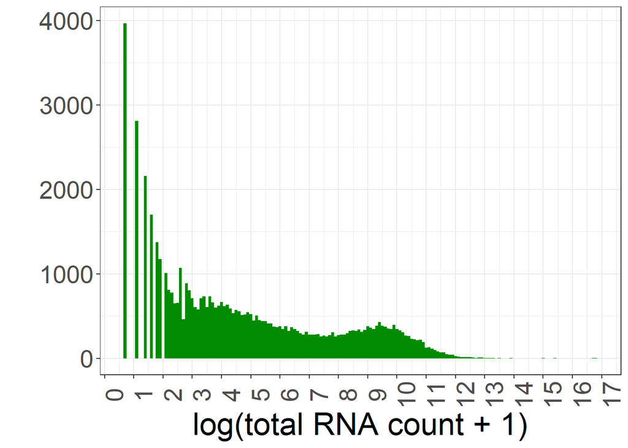

```r
#K562
#Log total RNA counts for each gene
logrowsums <- log1p(rowSums(assay(K562.se)))

ggplot(data = data.frame( x = logrowsums ), aes(x = x)) +
  geom_histogram(binwidth = 0.1, fill = "green4") +
  labs(x = "log(total RNA count + 1)", y = "") +
  scale_x_continuous(n.breaks = 20) +
  theme_bw() +
  theme(text=element_text(size=25), axis.text.x = element_text(angle = 90))
```

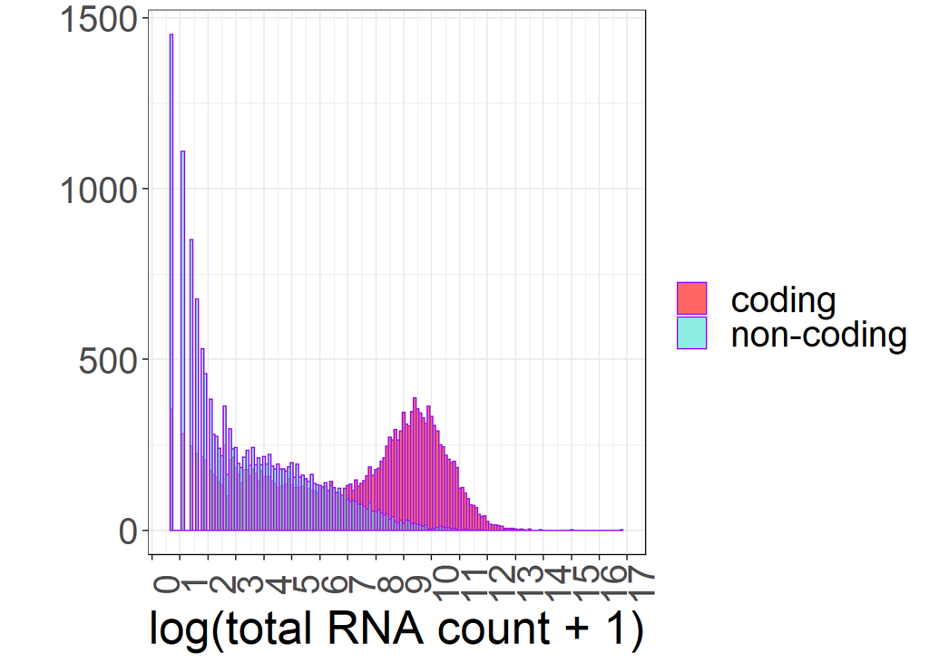

```r
#K562
#Log total RNA counts for non-coding and coding genes
logrowsums.nc <- log1p(rowSums(assay(se.nc)))
logrowsums.c <- log1p(rowSums(assay(se.c)))

ggplot(data = data.frame( x = c(logrowsums.nc, logrowsums.c),
                          label = c( rep("non-coding", length(logrowsums.nc)), rep("coding", length(logrowsums.c)) ) ),
       aes(x = x, fill = label)) +
  geom_histogram(binwidth = 0.1, color="purple", alpha=0.6, position = 'identity') +
  scale_fill_manual(values=c("red", "turquoise")) +
  labs(x = "log(total RNA count + 1)", fill="", y = "") +
  scale_x_continuous(n.breaks = 20) +
  theme_bw() +
  theme(text=element_text(size=25), axis.text.x = element_text(angle = 90))
```

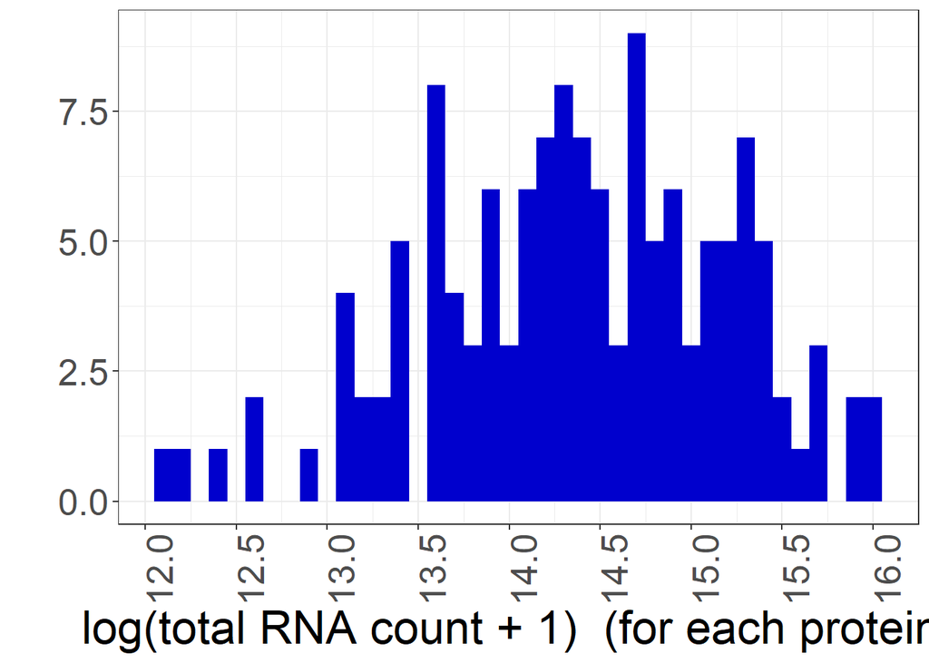

```r
#K562
#Log total RNA counts for each protein
logcolsums <- log1p(colSums(assay(K562.se)))

ggplot(data = data.frame( x = logcolsums ), aes(x = x)) +
  geom_histogram(binwidth = 0.1, fill = "blue3") +
  labs(x = "log(total RNA count + 1)  (for each protein)", y = "") +
  scale_x_continuous(n.breaks = 10) +
  theme_bw() +
  theme(text=element_text(size=25), axis.text.x = element_text(angle = 90))
```

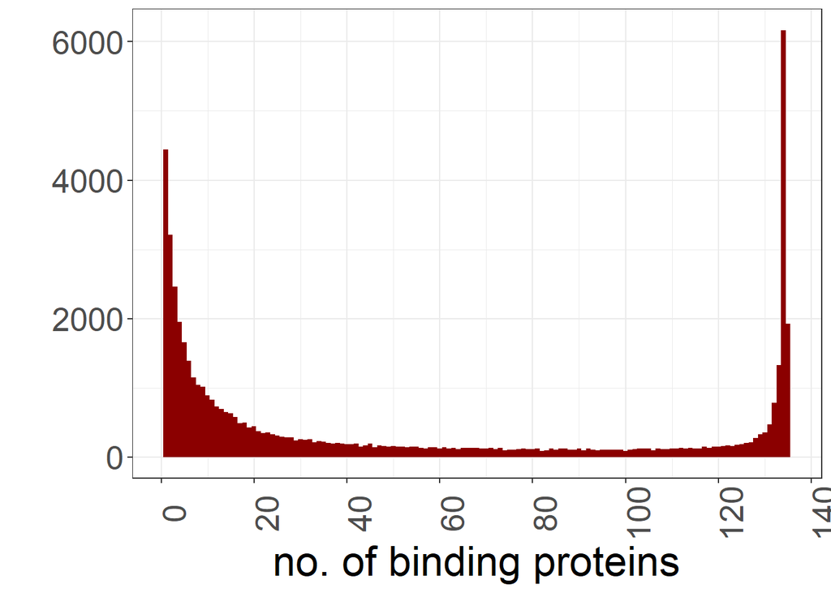

```r
#K562
#Number of proteins binding to each gene
proteinCount <- rowSums(assay(K562.se)!=0)

ggplot(data = data.frame( x = proteinCount ), aes(x = x)) +
  geom_histogram(binwidth = 1, fill = "red4") +
  labs(x = "no. of binding proteins", y = "") +
  scale_x_continuous(n.breaks = 10) +
  theme_bw() +
  theme(text=element_text(size=25), axis.text.x = element_text(angle = 90))
```

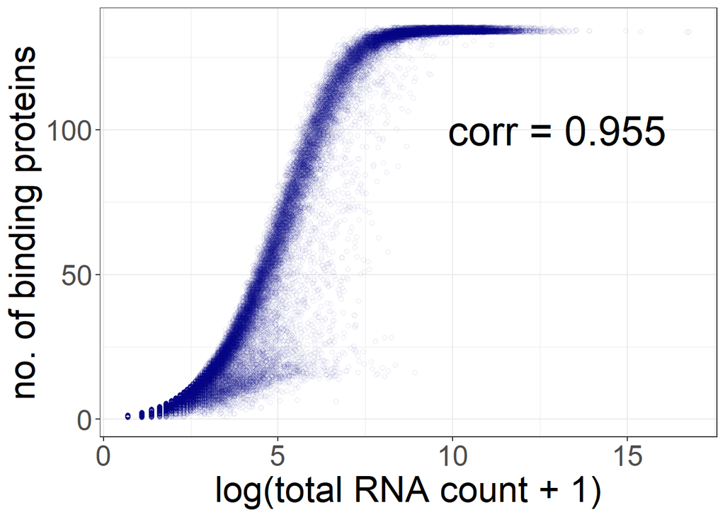

```r
#K562
#Relationship between log total RNA counts and number of binding proteins
ggplot(data = data.frame(x = logrowsums, y = proteinCount), aes(x = x, y = y)) +
  geom_jitter(shape = 1, color = "navy", alpha = 0.1) +
  annotate("text", x=13, y=100, label = paste0("corr = ",round(cor(logrowsums, proteinCount), digits = 3)), size = 10) +
  theme_bw() +
  theme(text=element_text(size=25)) +
  labs(x = "log(total RNA count + 1)", y = "no. of binding proteins")
```

We find that distribution of log total RNA counts for each gene has a long right tail. We also find that coding-genes have larger counts of RNA comparing to non-coding genes. The distribution of log total RNA counts for each protein is barely symmetric, and each protein binds a large quantity of RNA. The number of binding proteins looks bimodal, indicating that most RNA either specifically binds to a few kinds of proteins, or binds to a large spectrum of proteins. Besides, the number of log total RNA counts and the number of binding proteins for each gene are highly correlated. Thus we can simply determine a cutoff for gene filtering based on the distribution of RNA counts.

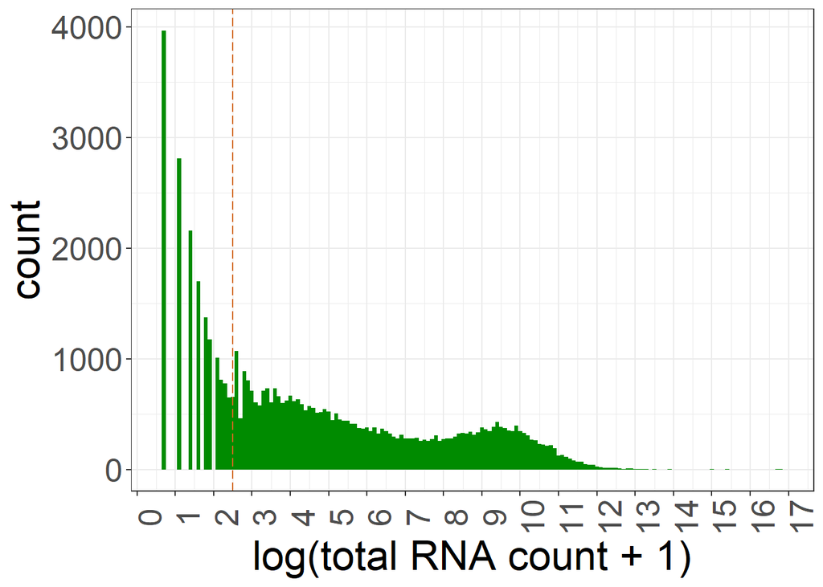

```r
#K562
cutoff = 2.5

ggplot(data = data.frame( x = logrowsums ), aes(x = x)) +
  geom_histogram(binwidth = 0.1, fill = "green4") +
  labs(x = "log(total RNA count + 1)") +
  scale_x_continuous(n.breaks = 20) +
  geom_vline(xintercept = cutoff, color = "chocolate", linetype = "longdash") +
  theme_bw() +
  theme(text=element_text(size=25), axis.text.x = element_text(angle = 90))
```

The cutoff is chosen as 11, or 2.5 in log scale. That is to say, we filter out genes with total RNA counts <= 11.

```r
#Labels for non-coding RNA
nc_labels <- c("lncRNA")
#Labels for coding RNA
c_labels <- c("protein_coding")

se.nc <- HEPG2.se[rowData(HEPG2.se)$Gene_type %in% nc_labels, ]

se.c <- HEPG2.se[rowData(HEPG2.se)$Gene_type %in% c_labels, ]
```

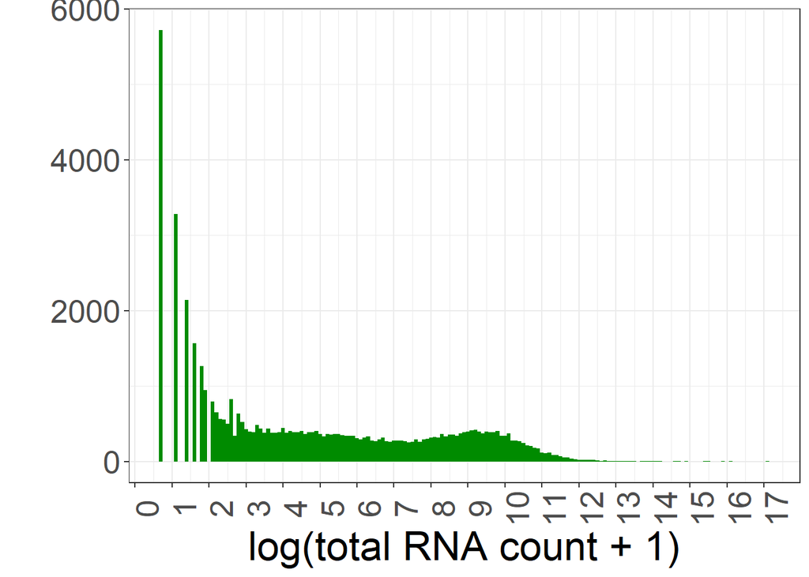

```r
#HEPG2
#Log total RNA counts for each gene
logrowsums <- log1p(rowSums(assay(HEPG2.se)))

ggplot(data = data.frame( x = logrowsums ), aes(x = x)) +
  geom_histogram(binwidth = 0.1, fill = "green4") +
  labs(x = "log(total RNA count + 1)", y = "") +
  scale_x_continuous(n.breaks = 20) +
  theme_bw() +
  theme(text=element_text(size=25), axis.text.x = element_text(angle = 90))
```

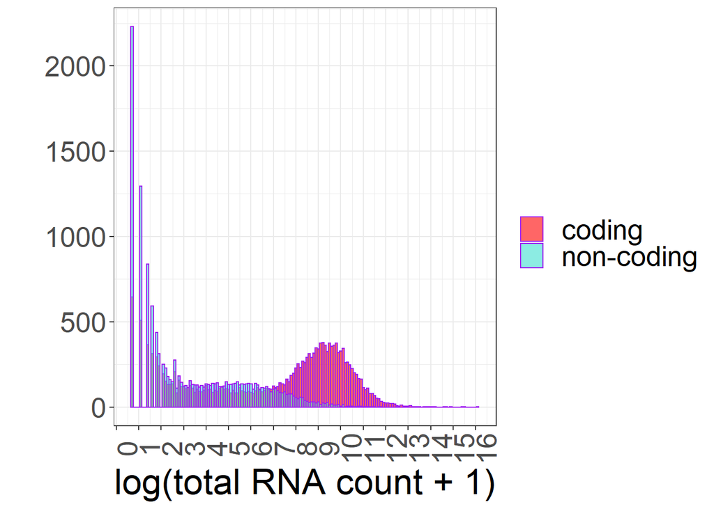

```r
#HEPG2
#Log total RNA counts for non-coding and coding genes
logrowsums.nc <- log1p(rowSums(assay(se.nc)))
logrowsums.c <- log1p(rowSums(assay(se.c)))

ggplot(data = data.frame( x = c(logrowsums.nc, logrowsums.c),
                          label = c( rep("non-coding", length(logrowsums.nc)), rep("coding", length(logrowsums.c)) ) ),
       aes(x = x, fill = label)) +
  geom_histogram(binwidth = 0.1, color="purple", alpha=0.6, position = 'identity') +
  scale_fill_manual(values=c("red", "turquoise")) +
  labs(x = "log(total RNA count + 1)", fill="", y = "") +
  scale_x_continuous(n.breaks = 20) +
  theme_bw() +
  theme(text=element_text(size=25), axis.text.x = element_text(angle = 90))
```

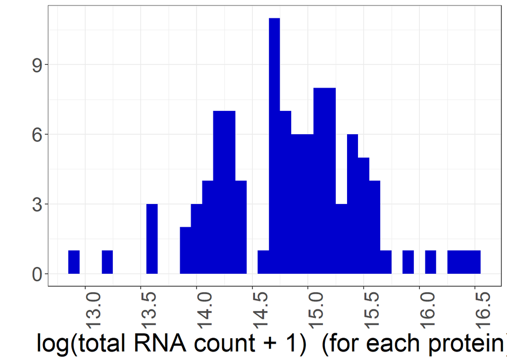

```r
#HEPG2
#Log total RNA counts for each protein
logcolsums <- log1p(colSums(assay(HEPG2.se)))

ggplot(data = data.frame( x = logcolsums ), aes(x = x)) +
  geom_histogram(binwidth = 0.1, fill = "blue3") +
  labs(x = "log(total RNA count + 1)  (for each protein)", y = "") +
  scale_x_continuous(n.breaks = 10) +
  theme_bw() +
  theme(text=element_text(size=25), axis.text.x = element_text(angle = 90))
```

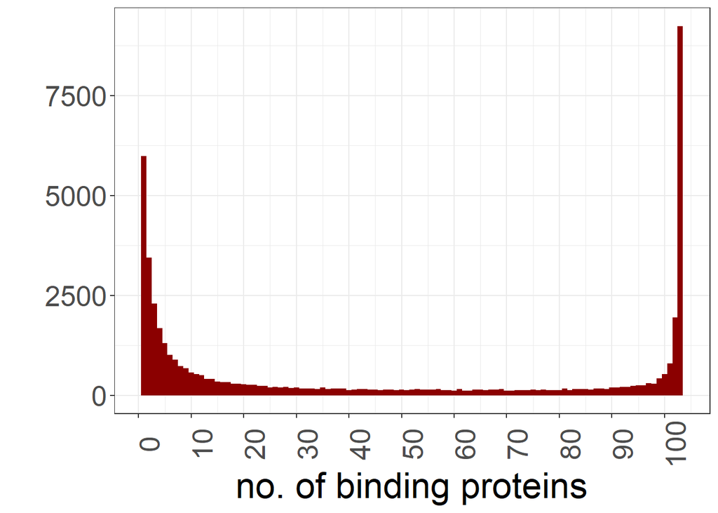

```r
#HEPG2
#Number of proteins binding to each gene
proteinCount <- rowSums(assay(HEPG2.se)!=0)

ggplot(data = data.frame( x = proteinCount ), aes(x = x)) +
  geom_histogram(binwidth = 1, fill = "red4") +
  labs(x = "no. of binding proteins", y = "") +
  scale_x_continuous(n.breaks = 10) +
  theme_bw() +
  theme(text=element_text(size=25), axis.text.x = element_text(angle = 90))
```

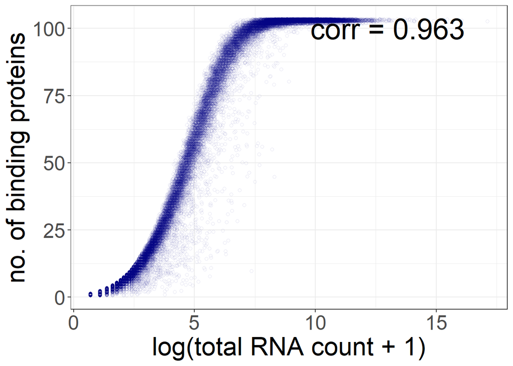

```r
#HEPG2
#Relationship between log total RNA counts and number of binding proteins
ggplot(data = data.frame(x = logrowsums, y = proteinCount), aes(x = x, y = y)) +
  geom_jitter(shape = 1, color = "navy", alpha = 0.1) +
  annotate("text", x=13, y=100, label = paste0("corr = ",round(cor(logrowsums, proteinCount), digits = 3)), size = 10) +
  theme_bw() +
  theme(text=element_text(size=25)) +
  labs(x = "log(total RNA count + 1)", y = "no. of binding proteins")
```

The patterns of HEPG2 data look similar to the ones we found in K562 data.

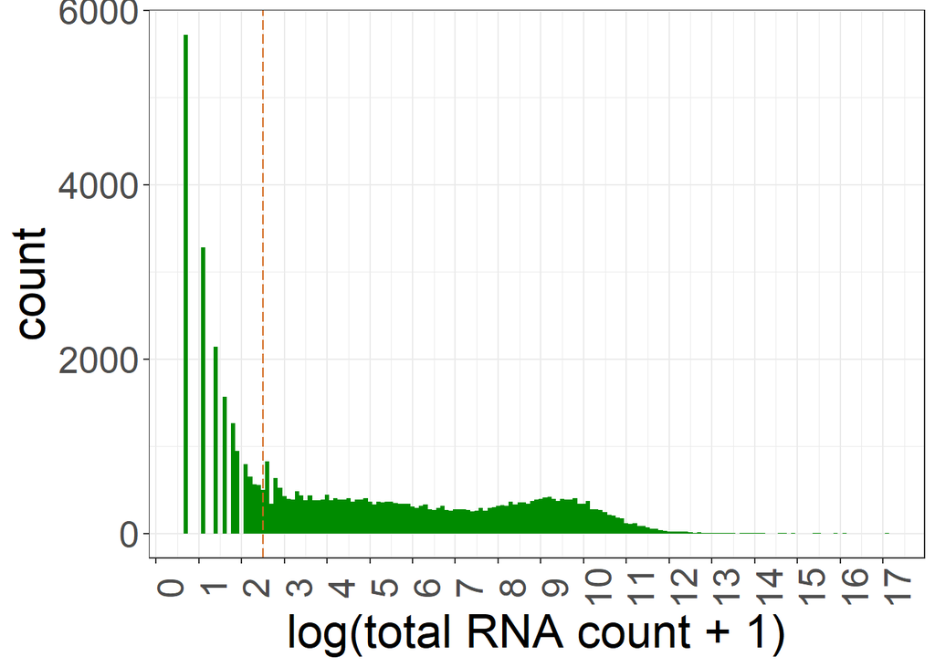

```r
#HEPG2
cutoff = 2.5

ggplot(data = data.frame( x = logrowsums ), aes(x = x)) +
  geom_histogram(binwidth = 0.1, fill = "green4") +
  labs(x = "log(total RNA count + 1)") +
  scale_x_continuous(n.breaks = 20) +
  geom_vline(xintercept = cutoff, color = "chocolate", linetype = "longdash") +
  theme_bw() +
  theme(text=element_text(size=25), axis.text.x = element_text(angle = 90))
```

The cutoff chosen is the same as the one for K562 data. We filter out genes with total RNA counts <= 11 for HEPG2 data.

### Compare non-coding vs. coding genes on protein binding

We start from filtered datasets.

```r
rowTotal = 11
keep <- rowSums(assay(K562.se)) > rowTotal
K562.se <- K562.se[keep,]

se.nc <- K562.se[rowData(K562.se)$Gene_type %in% nc_labels, ]

se.c <- K562.se[rowData(K562.se)$Gene_type %in% c_labels, ]

mtx.nc <- assay(se.nc)

mtx.c <- assay(se.c)
```

```r
#K562
#Wilcoxon
data.result.wilcox <- data.frame(protein = colnames(K562.se), p.val = NA, log2fc = NA)

for (i in 1:ncol(K562.se)) {
  test <- wilcox.test(mtx.nc[,i], mtx.c[,i], alternative = "two.sided")

  data.result.wilcox$p.val[i] <- test$p.value

  fc <- mean(mtx.nc[,i])/mean(mtx.c[,i])

  data.result.wilcox$log2fc[i] <- log2(fc)

}

data.result.wilcox <- data.result.wilcox %>% mutate(p.val.adj = p.adjust(p.val, method = "BH"))
data.result.wilcox
```

```
##         protein        p.val      log2fc    p.val.adj
## 1   ENCSR795CAI 0.000000e+00 -1.24682920 0.000000e+00
## 2   ENCSR456KXI 0.000000e+00 -2.69350749 0.000000e+00
## 3   ENCSR308YNT 0.000000e+00 -3.80854613 0.000000e+00
## 4   ENCSR438KWZ 0.000000e+00 -2.01614597 0.000000e+00
## 5   ENCSR023PKW 0.000000e+00 -1.88604182 0.000000e+00
## 6   ENCSR887LPK 0.000000e+00 -1.19655133 0.000000e+00
## 7   ENCSR970NKP 0.000000e+00 -3.61627531 0.000000e+00
## 8   ENCSR366YOG 0.000000e+00 -2.19492084 0.000000e+00
## 9   ENCSR206RXT 0.000000e+00 -1.57103800 0.000000e+00
## 10  ENCSR534YOI 0.000000e+00 -2.90376434 0.000000e+00
## 11  ENCSR089BXO 0.000000e+00 -3.33481605 0.000000e+00
## 12  ENCSR767OEY 0.000000e+00 -3.55717839 0.000000e+00
## 13  ENCSR819XBT 0.000000e+00 -1.43254443 0.000000e+00
## 14  ENCSR381VNR 0.000000e+00 -2.31114283 0.000000e+00
```

[output cut: 121 more lines]

```r
#K562
#ZINB
# data.result.zinb <- data.frame(protein = colnames(K562.se), p.val = NA, log2fc = NA)
#
# for (i in 1:ncol(K562.se)) {
#
#   dat <- data.frame( count = c(mtx.nc[,i], mtx.c[,i]),
#               label = c( rep(1, nrow(mtx.nc)), rep(0, nrow(mtx.c)) ) )
#
#   m1 <- glmmTMB(count ~ label, data = dat, ziformula = ~., family = nbinom2(link = "log"))
#
#   # null model
#
#   m0 <- update(m1, . ~ 1)
#
#   pval = pchisq(2 * (logLik(m1) - logLik(m0)), df = 2, lower.tail=FALSE)
#   pval = as.numeric(pval)
#
#   data.result.zinb$p.val <- pval
#
#   fc <- mean(mtx.nc[,i])/mean(mtx.c[,i])
#
#   data.result.zinb$log2fc[i] <- log2(fc)
#
#   print(i)
# }
#
# data.result.zinb

#The resutls are saved in K562_zinb.csv
```

```r
rowTotal = 11
keep <- rowSums(assay(HEPG2.se)) > rowTotal
HEPG2.se <- HEPG2.se[keep,]

se.nc <- HEPG2.se[rowData(HEPG2.se)$Gene_type %in% nc_labels, ]

se.c <- HEPG2.se[rowData(HEPG2.se)$Gene_type %in% c_labels, ]

mtx.nc <- assay(se.nc)

mtx.c <- assay(se.c)
```

```r
#HEPG2
#Wilcoxon
data.result.wilcox <- data.frame(protein = colnames(HEPG2.se), p.val = NA, log2fc = NA)

for (i in 1:ncol(HEPG2.se)) {
  test <- wilcox.test(mtx.nc[,i], mtx.c[,i], alternative = "two.sided")

  data.result.wilcox$p.val[i] <- test$p.value

  fc <- mean(mtx.nc[,i])/mean(mtx.c[,i])

  data.result.wilcox$log2fc[i] <- log2(fc)

}

data.result.wilcox <- data.result.wilcox %>% mutate(p.val.adj = p.adjust(p.val, method = "BH"))
data.result.wilcox
```

```
##         protein p.val      log2fc p.val.adj
## 1   ENCSR987FTF     0 -1.24373330         0
## 2   ENCSR993OLA     0 -3.55480028         0
## 3   ENCSR240MVJ     0 -0.41133662         0
## 4   ENCSR018RVZ     0 -2.22019193         0
## 5   ENCSR970FEW     0 -2.15285587         0
## 6   ENCSR685AUR     0 -4.01470089         0
## 7   ENCSR356ZMO     0 -3.49321725         0
## 8   ENCSR766FAC     0 -4.71865309         0
## 9   ENCSR979EWD     0 -1.33642023         0
## 10  ENCSR279UJF     0 -2.64551878         0
## 11  ENCSR993FMY     0 -1.50571418         0
## 12  ENCSR351PVI     0 -1.54488584         0
## 13  ENCSR786TSC     0 -2.32705611         0
## 14  ENCSR834YLD     0 -2.05015046         0
```

[output cut: 89 more lines]

```r
#HEPG2
#ZINB
# data.result.zinb <- data.frame(protein = colnames(HEPG2.se), p.val = NA, log2fc = NA)
#
# for (i in 1:ncol(HEPG2.se)) {
#
#   dat <- data.frame( count = c(mtx.nc[,i], mtx.c[,i]),
#               label = c( rep(1, nrow(mtx.nc)), rep(0, nrow(mtx.c)) ) )
#
#   m1 <- glmmTMB(count ~ label, data = dat, ziformula = ~., family = nbinom2(link = "log"))
#
#   # null model
#
#   m0 <- update(m1, . ~ 1)
#
#   pval = pchisq(2 * (logLik(m1) - logLik(m0)), df = 2, lower.tail=FALSE)
#   pval = as.numeric(pval)
#
#   data.result.zinb$p.val <- pval
#
#   fc <- mean(mtx.nc[,i])/mean(mtx.c[,i])
#
#   data.result.zinb$log2fc[i] <- log2(fc)
#
#   print(i)
# }
#
# data.result.zinb

#The resutls are saved in HEPG2_zinb.csv
```

All p-values are very close to 0. This suggests a huge discrepancy between non-coding and coding genes on protein binding.

Since the p-values are all around 0, we turn to focus on log2 fold changes.

```r
#Results from ZINB model
data.k562 <- read.csv("developing_se/K562_se/K562_zinb.csv", stringsAsFactors = FALSE)
data.hepg2 <- read.csv("developing_se/HEPG2_se/HEPG2_zinb.csv", stringsAsFactors = FALSE)
```

```r
###Add the columns for the experiment target

data.k562$target <- colData(K562.se)$Experiment.target

data.hepg2$target <- colData(HEPG2.se)$Experiment.target

data.joint <- inner_join(data.k562, data.hepg2, by = "target", suffix = c(".k", ".h"))
```

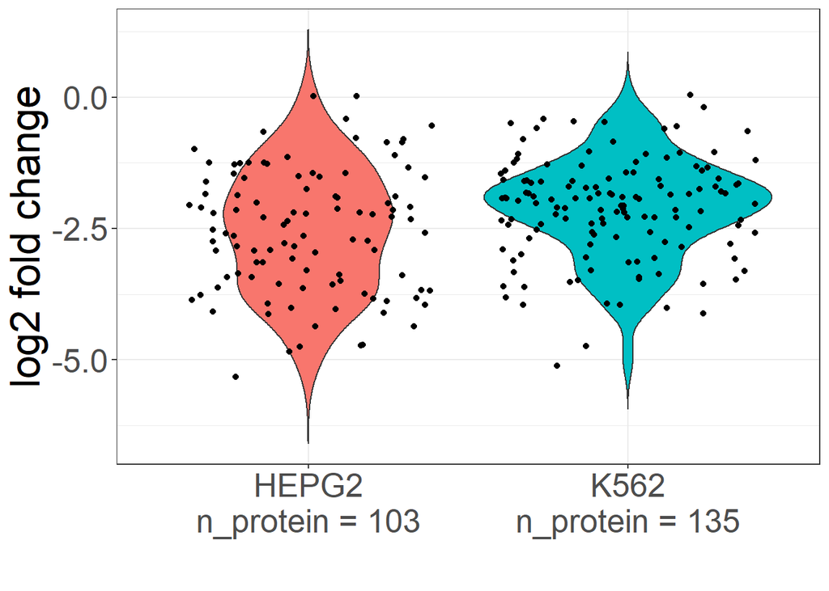

```r
###Violin plot of log2 fold changes
data.k562$cell_line <- "K562"
data.hepg2$cell_line <- "HEPG2"
data.merged <- bind_rows(data.k562, data.hepg2)

ggplot(data = data.merged, aes(x = cell_line, y = log2fc, fill = cell_line)) +
  geom_violin(trim = FALSE) +
  geom_jitter(height = 0) +
  scale_x_discrete(labels = c("HEPG2" = "HEPG2\nn_protein = 103",
                              "K562" = "K562\nn_protein = 135")) +
  labs(x="", y="log2 fold change") +
  theme_bw() +
  theme(text=element_text(size=25), legend.position = "none")
```

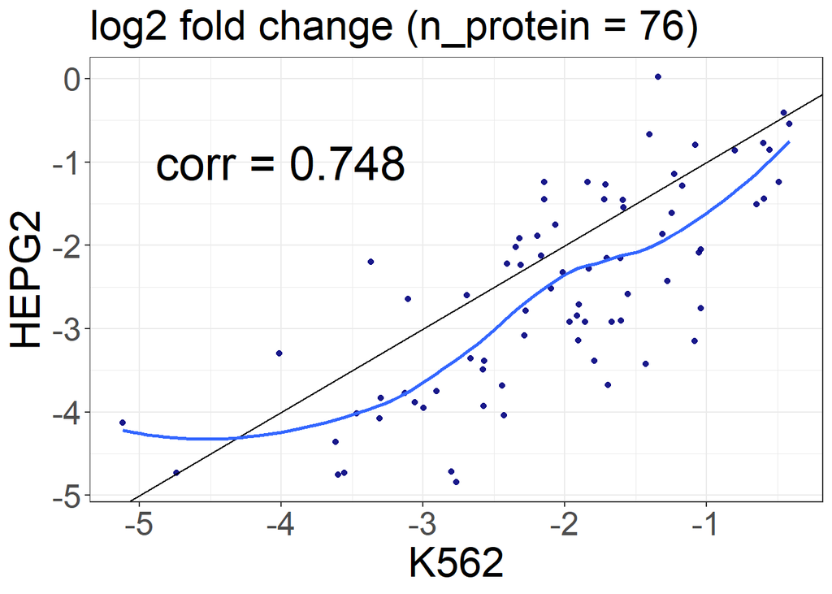

```r
###Scatter plot of log2 fold changes on shared genes
ggplot(data = data.joint, aes(x = log2fc.k, y = log2fc.h)) +
  geom_point(color = "navy", alpha = .9) +
  geom_abline(slope = 1, intercept = 0) +
  geom_smooth(method = "loess", se = F) +
  annotate("text", x=-4, y=-1, label = paste0("corr = ",round(cor(data.joint$log2fc.k, data.joint$log2fc.h), digits = 3)), size = 10) +
  theme_bw() +
  theme(text=element_text(size=25)) +
  labs(x = "K562", y = "HEPG2", subtitle = paste0("log2 fold change (n_protein = ",nrow(data.joint),")") )
```

The log2 fold changes of the shared genes across the two datases are correlated. Althought the p-values are really close to 0, there are three proteins have log2 fold changes around 0, which looks weird.

```r
#Separate those three genes
data.merged2 <- data.merged[order(data.merged$log2fc, decreasing = T),]
data.merged2[1:3,]
```

```
##         protein p.val     log2fc       target cell_line
## 76  ENCSR943MHU     0 0.04569017  SAFB2-human      K562
## 164 ENCSR965DLL     0 0.02477489   SFPQ-human     HEPG2
## 215 ENCSR267UCX     0 0.01848052 HNRNPM-human     HEPG2
```